# Basic data visualization in R

# Introduction

This is a notebook comparable to that created by Kerby Shedden in his series that focuses on Python ([link](http://nbviewer.jupyter.org/urls/umich.box.com/shared/static/0iffa0dcjfmaayvr6bp36x3nrk95flyq.ipynb)). This notebook attempts to reproduce that one as much as possible, and at times I will reference Python where appropriate.

This notebook illustrates some basic techniques for visualization in R. Here we focus on some more basic plotting approaches just to get started.

There are many R packages that support visualization. Base R provides fine grain control such that one can create ‘publication-quality’ graphs. Unfortuntately, publication-quality is a fairly low bar, and the defaults for things like scatterplots, histograms etc. in R are borderline unusable, lacking sensible default settings. As such I will not focus on the base R approach, but for the interested one can see the plot, hist, barplot functions for starters.

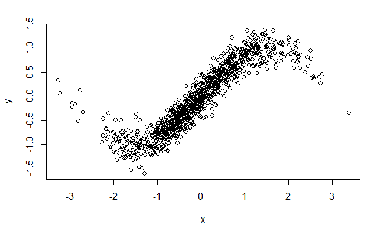

```r
x = rnorm(1000)
y = sin(x) + rnorm(1000, sd=.2)
df = data.frame(x, y)
plot(x, y)
```

```r
library(plotly)
plot_ly(x=x, y=y, mode='markers')
```

[interactive chart not shown]

Here we focus on a few packages:

- ggplot2
- plotly
- htmlwidgets

# Preliminaries

To illustrate the visualization techniques, we will use some of the NHANES (National Health and Nutrition Examination Study) data:

- [Demograpics: https://wwwn.cdc.gov/Nchs/Nhanes/2009-2010/DEMO_F.XPT](https://wwwn.cdc.gov/Nchs/Nhanes/2009-2010/DEMO_F.XPT)
- [Blood Pressure: https://wwwn.cdc.gov/Nchs/Nhanes/2009-2010/BPX_F.XPT](https://wwwn.cdc.gov/Nchs/Nhanes/2009-2010/BPX_F.XPT)
- [Body Measures: https://wwwn.cdc.gov/Nchs/Nhanes/2009-2010/BMX_F.XPT](https://wwwn.cdc.gov/Nchs/Nhanes/2009-2010/BMX_F.XPT)

```r
library(foreign)
demo = read.xport("data/DEMO_F.XPT")
bpx = read.xport("data/BPX_F.XPT")
bmx = read.xport("data/BMX_F.XPT")
nhanes = plyr::join_all(list(demo, bpx, bmx))
head(colnames(nhanes))  # first 6 columns
```

```
[1] "SEQN"     "SDDSRVYR" "RIDSTATR" "RIDEXMON" "RIAGENDR" "RIDAGEYR"
```

## Variable Descriptions

More detail can be found [here](http://wwwn.cdc.gov/nchs/nhanes/search/nhanes09_10.aspx).

Demographics:

- SEQN - Respondent sequence number
- SDDSRVYR - Data Release Number
- RIDSTATR - Interview/Examination Status
- RIDEXMON - Six month time period
- RIAGENDR - Gender
- RIDAGEYR - Age at Screening Adjudicated - Recode
- RIDAGEMN - Age in Months at Screening - Recode
- RIDAGEEX - Age in Months at Exam - Recode
- RIDRETH1 - Race/Ethnicity - Recode
- DMQMILIT - Served in the US Armed Forces
- DMDBORN2 - Country of Birth - Recode
- DMDCITZN - Citizenship Status
- DMDYRSUS - Length of time in US
- DMDEDUC3 - Education Level - Children/Youth 6-19
- DMDEDUC2 - Education Level - Adults 20+
- DMDSCHOL - Now attending school?
- DMDMARTL - Marital Status
- DMDHHSIZ - Total number of people in the Household
- DMDFMSIZ - Total number of people in the Family
- INDHHIN2 - Annual Household Income
- INDFMIN2 - Annual Family Income
- INDFMPIR - Ratio of family income to poverty
- RIDEXPRG - Pregnancy Status at Exam - Recode
- DMDHRGND - HH Ref Person Gender
- DMDHRAGE - HH Ref Person Age
- DMDHRBR2 - HH Ref Person Country of Birth
- DMDHREDU - HH Ref Person Education Level
- DMDHRMAR - HH Ref Person Marital Status
- DMDHSEDU - HH Ref Person’s Spouse Education Level
- SIALANG - Language of SP Interview
- SIAPROXY - Proxy used in SP Interview?
- SIAINTRP - Interpreter used in SP Interview?
- FIALANG - Language of Family Interview
- FIAPROXY - Proxy used in Family Interview?
- FIAINTRP - Interpreter used in Family Interview?
- MIALANG - Language of MEC Interview
- MIAPROXY - Proxy used in MEC Interview?
- MIAINTRP - Interpreter used in MEC Interview?
- AIALANG - Language of ACASI Interview
- WTINT2YR - Full Sample 2 Year Interview Weight
- WTMEC2YR - Full Sample 2 Year MEC Exam Weight
- SDMVPSU - Masked Variance Pseudo-PSU
- SDMVSTRA - Masked Variance Pseudo-Stratum

Blood Pressure:

- SEQN - Respondent sequence number
- PEASCST1 - Blood Pressure Status
- PEASCTM1 - Blood Pressure Time in Seconds
- PEASCCT1 - Blood Pressure Comment
- BPXCHR - 60 sec HR (30 sec HR * 2)
- BPQ150A - Had food in the past 30 minutes?
- BPQ150B - Had alcohol in the past 30 minutes?
- BPQ150C - Had coffee in the past 30 minutes?
- BPQ150D - Had cigarettes in the past 30 minutes?
- BPAARM - Arm selected:
- BPACSZ - Coded cuff size
- BPXPLS - 60 sec. pulse (30 sec. pulse * 2):
- BPXPULS - Pulse regular or irregular?
- BPXPTY - Pulse type:
- BPXML1 - MIL: maximum inflation levels (mm Hg)
- BPXSY1 - Systolic: Blood pres (1st rdg) mm Hg
- BPXDI1 - Diastolic: Blood pres (1st rdg) mm Hg
- BPAEN1 - Enhancement used first reading
- BPXSY2 - Systolic: Blood pres (2nd rdg) mm Hg
- BPXDI2 - Diastolic: Blood pres (2nd rdg) mm Hg
- BPAEN2 - Enhancement used second reading
- BPXSY3 - Systolic: Blood pres (3rd rdg) mm Hg
- BPXDI3 - Diastolic: Blood pres (3rd rdg) mm Hg
- BPAEN3 - Enhancement used third reading
- BPXSY4 - Systolic: Blood pres (4th rdg) mm Hg
- BPXDI4 - Diastolic: Blood pres (4th rdg) mm Hg
- BPAEN4 - Enhancement used fourth reading

Body Measures:

- SEQN - Respondent sequence number
- BMDSTATS - Body Measures Component Status Code
- BMXWT - Weight (kg)
- BMIWT - Weight Comment
- BMXRECUM - Recumbent Length (cm)
- BMIRECUM - Recumbent Length Comment
- BMXHEAD - Head Circumference (cm)
- BMIHEAD - Head Circumference Comment
- BMXHT - Standing Height (cm)
- BMIHT - Standing Height Comment
- BMXBMI - Body Mass Index (kg/m**2)
- BMXLEG - Upper Leg Length (cm)
- BMILEG - Upper Leg Length Comment
- BMXARML - Upper Arm Length (cm)
- BMIARML - Upper Arm Length Comment
- BMXARMC - Arm Circumference (cm)
- BMIARMC - Arm Circumference Comment
- BMXWAIST - Waist Circumference (cm)
- BMIWAIST - Waist Circumference Comment
- BMXTRI - Triceps Skinfold (mm)
- BMITRI - Triceps Skinfold Comment
- BMXSUB - Subscapular Skinfold (mm)
- BMISUB - Subscapular Skinfold Comment

# ggplot2

ggplot2 is a powerful visualization package that makes getting standard plots of the sort we typically want very easy. It is based on Hadley Wickham’s (of RStudio) grammar of graphics. There are now dozens of packages that add additional functionality, and other packages use it for package specific visualization. For static plots it serves as a foundation. A [cheatsheet](https://www.rstudio.com/wp-content/uploads/2015/03/ggplot2-cheatsheet.pdf) is provided for quick reference.

## Scatterplot

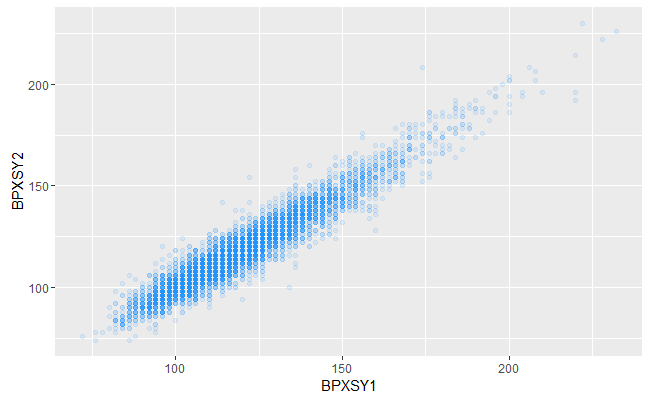

```r
library(ggplot2)
ggplot(aes(x=BPXSY1, y=BPXSY2), data=nhanes) +
  geom_point(color='dodgerblue', alpha=.1)
```

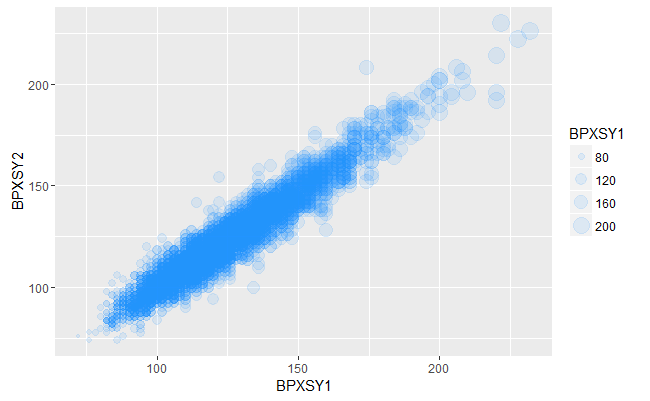

```r
ggplot(aes(x=BPXSY1, y=BPXSY2), data=nhanes) +
  geom_point(aes(size=BPXSY1), color='dodgerblue', alpha=.1)
```

## Density plot

Here is a basic density plot for the first measure.

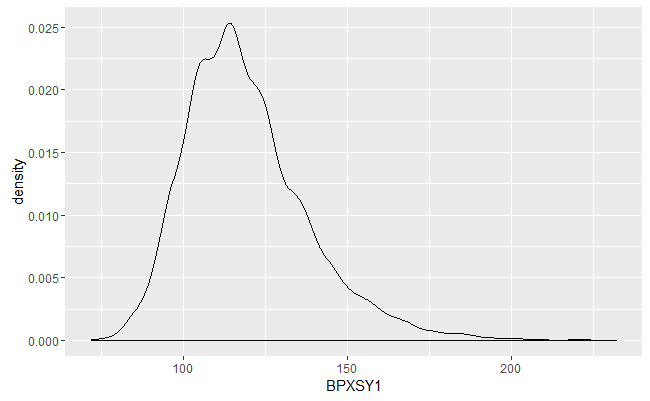

```r
ggplot(aes(x=BPXSY1), data=nhanes) +
  geom_density()
```

Let’s split it out by gender. Remember piping (see previous workshop)? We can do that here, and on-the-fly visuals is one of the best uses for it, because it allows us to create new variables and objects without cluttering the environment with objects we only need temporarily. Note that aesthetics in the first ggplot source will be potentially supplied to the rest, while we can use aesthetics specific to a geom at the point the geom is introduced.

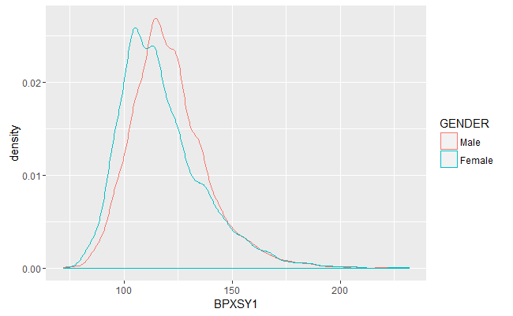

```r
library(dplyr)
# nhanes$GENDER = factor(nhanes$RIAGENDR, labels = c('Male', 'Female'))
nhanes %>%
  mutate(GENDER = factor(nhanes$RIAGENDR, labels = c('Male', 'Female'))) %>%
  ggplot(aes(x=BPXSY1)) +
  geom_density(aes(color=GENDER))
```

Note that color for a density plot only refers to the stroke, when we might want to use the fill instead.

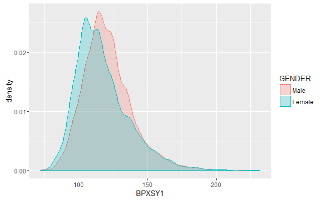

```r
nhanes$GENDER = factor(nhanes$RIAGENDR, labels = c('Male', 'Female'))
ggplot(aes(x=BPXSY1), data=nhanes) +
  geom_density(aes(color=GENDER, fill=GENDER), alpha=.25)
```

## Examples

Just a brief foray into other geoms.

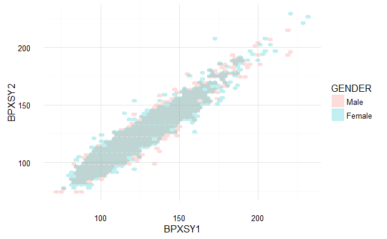

```r
ggplot(aes(x=BPXSY1, y=BPXSY2), data=nhanes) +
  geom_hex(aes(fill=GENDER), alpha=.25, bins=50) +
  theme_minimal()
```

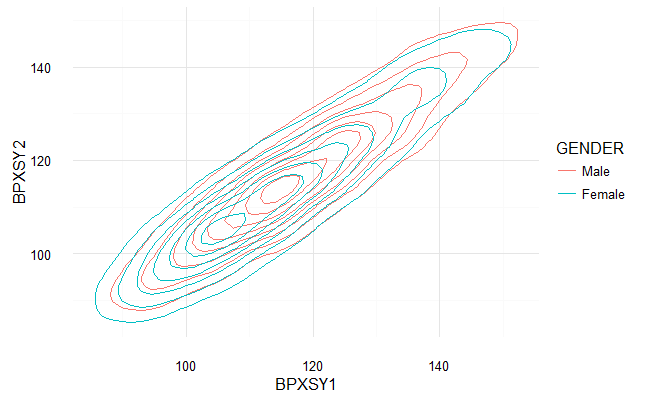

```r
ggplot(data=nhanes) +
  geom_density_2d(aes(x=BPXSY1, y=BPXSY2, color=GENDER)) +
  # stat_density_2d(aes(fill = ..level..), geom = "polygon") +
  theme_minimal()
```

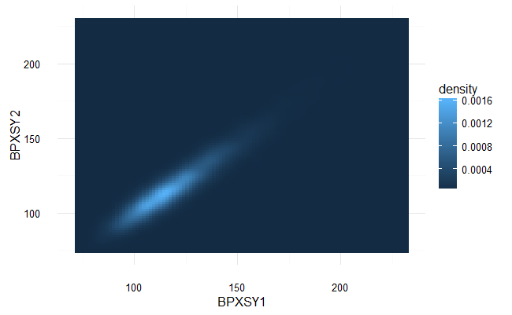

```r
ggplot(data=nhanes) +
  stat_density_2d(aes(x=BPXSY1, y=BPXSY2, fill=..density..), geom = "raster", contour=FALSE) +
  theme_minimal()
```

There are many packages that enhance the functionality of ggplot2. Consider ggExtra as a starting point. As an example, one of the additions it provides is the ability to add marginal histograms to a plot

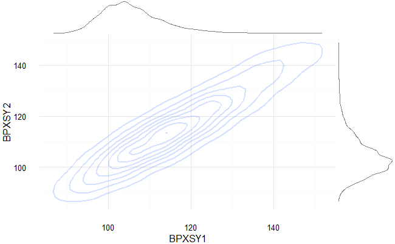

```r
scatter_plot = ggplot(data=nhanes) +
    geom_density2d(aes(x=BPXSY1, y=BPXSY2), alpha=.2, lwd=1) +
    theme_minimal()
ggExtra::ggMarginal(scatter_plot, type='density', color='gray50')
```

Not only does it allow for histogram marginals, the package provides an *addin* for interactive creation of such a plot. Notably less efficient, *unless* you are trying out differnt colors, line widths etc., in which case you won’t need to rerun code with every change. To use it, just highlight the ggplot code, e.g. that contains the scatterplot, and click the addin. Here is a screen shot.

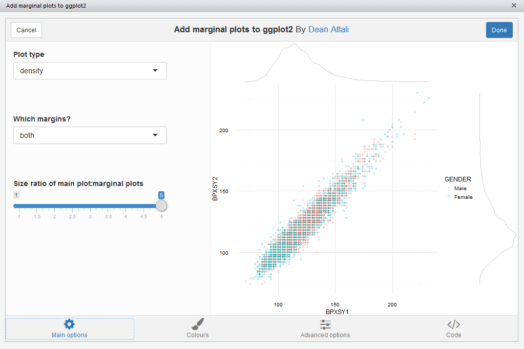

## Facets

An extremely common operation is to break out plots by group. Facets allow us to do this via facet_wrap and facet_grid. The difference between the two is that **wrap** is more flexible (i.e. you can generally make any **grid** plot with **wrap**), but often what you want is essentially what **grid** provides by default.

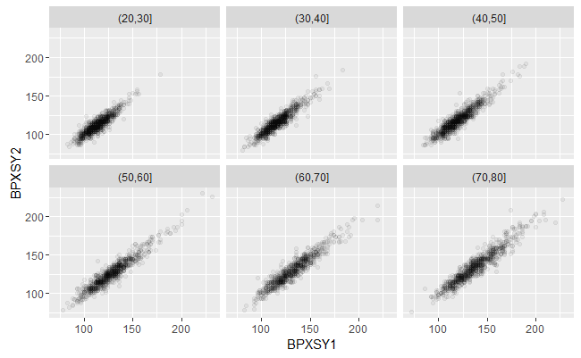

```r
nhanes %>%
  mutate(ageGrps = factor(cut(RIDAGEYR, breaks=c(20, 30, 40, 50, 60, 70, 80)))) %>%
  select(BPXSY1, BPXSY2, ageGrps) %>%
  na.omit %>%
  ggplot(aes(x=BPXSY1, y=BPXSY2)) +
  geom_point(alpha=.05) +
  facet_wrap(~ageGrps)
```

## Themes

If you’re like me, you might think that gray is a pretty poor choice for a default background (unfortunately other software/language modules have copied the ggplot2 approach as well). We can specify the overall look of things via the theme layer, but several themes come with ggplot2. In the following I use a minimal theme, which for some reason retains unnecessary gridlines, so I remove those[^1].

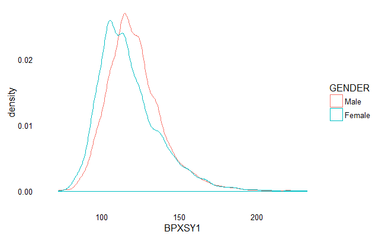

```r
ggplot(aes(x=BPXSY1), data=nhanes) +
  geom_density(aes(color=GENDER)) +
  theme_minimal() +
  theme(panel.grid=element_blank())
```

For more details, see the helpfile `?theme`.

# Interactivity

Interactive plots in R are generally very easy, and as they can be saved as static png or other files, there’s little reason not to make interactive plots from the getgo. Most of the more recent packages use javascript libraries, but you do not have to know any javascript to create them.

Some packages to note:

- htmlwidgets The htmlwidgets package allows an R interface to javascript libraries. A collection of useful packages can be found [here](http://www.htmlwidgets.org/).
- plotly
  - used also in Python, Matlab, Julia, aside from many interactive plots, can convert ggplot2 images to interactive ones.
- rbokeh
  - like plotly, bokeh also has cross program support
- ggvis
  - interactive successor to to ggplot though not currently actively developed[^2]

Here are a couple examples using plotly. For basic plots, even maps, it can be fairly easy to use, plus you can send your ggplot creation to it.

The following shows how to use some options. For plotly, we work with traces as opposed to the geoms of ggplot, and we use the standard pipes, but much of the approach is similar. We start with a base plot and add layers.

[interactive chart not shown]

Although adding smooths on scatterplots is an extremely common option, plotly doesn’t provide a trace for it so some pre-processing had to be done. Fortunately, ggplot2 has such functionality, so we could have started there.

```r
p = ggplot(aes(x=RIDAGEYR, y=BMXBMI), data=nhanes) +
  geom_point(color='#1e90ff', alpha=.2) +
  geom_smooth(color='#ff5509', se=F) +
  theme_minimal()
ggplotly()
```

[interactive chart not shown]

The following example shows how we can do some data manipulation prior to the visualization.

```r
nhanes %>%
  select(GENDER, RIDRETH1, BPXSY1, BMXBMI) %>%
  mutate(RACE = factor(RIDRETH1, labels=c('MexiAmer', 'OtherHisp', 'NonHispWhite', 'NonHispBlack', 'Other'))) %>%
  rename(BP = BPXSY1,
         BMI = BMXBMI) %>%
  group_by(GENDER, RACE) %>%
  select(BP, BMI, RACE, GENDER) %>%
  summarize(meanBMI = mean(BMI, na.rm=T),
            meanBP = mean(BP, na.rm=T)) %>%
  plot_ly(x=RACE, y=meanBMI, color=GENDER, mode='markers', size=meanBP,
          marker=list(sizeref=10))
```

[interactive chart not shown]

Here is the map[^3] example from the plotly website.

```r
library(plotly)
df <- read.csv("https://raw.githubusercontent.com/plotly/datasets/master/2011_us_ag_exports.csv")
df$hover <- with(df, paste(state, '<br>', "Beef", beef, "Dairy", dairy, "<br>",
                           "Fruits", total.fruits, "Veggies", total.veggies,
                           "<br>", "Wheat", wheat, "Corn", corn))
# give state boundaries a white border
l <- list(color = toRGB("white"), width = 2)
# specify some map projection/options
g <- list(
  scope = 'usa',
  projection = list(type = 'albers usa'),
  showlakes = TRUE,
  lakecolor = toRGB('white')
)
plot_ly(df, z = total.exports, text = hover, locations = code, type = 'choropleth',
        locationmode = 'USA-states', color = total.exports, colors = 'Purples',
        marker = list(line = l), colorbar = list(title = "Millions USD")) %>%
  layout(title = '2011 US Agriculture Exports by State<br>(Hover for breakdown)', geo = g)
```

[interactive chart not shown]

```r
plot_ly(z=volcano, type='surface')
```

[interactive chart not shown]

A word about using plotly. I like what I’ve been able to do with it, but I don’t find it easy to work with once you go beyond your basic sorts of visualizations, though this is almost entirely due to the poor [documentation](https://plot.ly/r/), which is pretty terrible in both layout and detail. When you can find an interesting example (most stop at the simplest demonstrations), it typically won’t contain text or comments outlining the ‘why’ of the code. In many cases, I’ve found it easier to look at the python examples or go to the javascript library documentation itself to see better examples and what is possible. Furthermore, the pages load *every* plot, and the plots are not small in web browsing terms, so some pages will take a bit to load even with a decent internet connection (e.g. this document is over 4mb). Unfortunately, aside from a couple examples, the help files within R just point you to the web for detail, and since there are few working examples for many of the options, it’s hard to pinpoint why a plot doesn’t do what you want[^4].

The pros of plotly are the easy interactivity, the easy ability to export the plots from within the webpage they are part of, and the ability to work with ggplot2, which is huge. However, if they are appropriate, I’d suggest using some of the packages on the htmlwidgets page, or others for specific needs.

# Summary

Visualization is essential to any good analysis. The days when bar plots and plots with only 2d information were adequate for conveying model results have long since passed. R provides a host of graphical options that can surely meet your needs, and often quite easily, even for more complex settings. You can have a lot of fun exploring your data with these tools!

[^1]: I have clean [themes](https://github.com/m-clark/lazerhawk) for ggplot2, plotly, and ggvis.
[^2]: The last meaningful update was early 2015, about 6 months after its *first* big update. I figure the reason it has largely been abandoned is that so many other interactive tools came along around the same time, including some developed by the same folks. It’s not clear to me what it can add at this point, and given the lack of development I can’t recommend it.
[^3]: Plotly maps are not visible in the viewer, but will show up in your browser.
[^4]: Something that gets me often is that even though the traces are plural (*markers*, *lines*), the option list to set them isn’t (e.g. `marker = list()`), but if you happen to make this typo it won’t throw an error.